# Risk Factor Analysis

## Outcome Variable

**Outcome Variable:** pers_wast

## Predictor Variables

**Intervention Variable:** parity

**Adjustment Set:**

unadjusted

## Stratifying Variables

The analysis was stratified on these variable(s):

- agecat
- studyid
- country

## Data Summary

| agecat | studyid | country | parity | pers_wast | n_cell | n | outcome_variable |
| --- | --- | --- | --- | --- | --- | --- | --- |
| 0-24 months | ki1000304b-SAS-CompFeed | INDIA | 1 | 0 | 378 | 1366 | pers_wast |
| 0-24 months | ki1000304b-SAS-CompFeed | INDIA | 1 | 1 | 30 | 1366 | pers_wast |
| 0-24 months | ki1000304b-SAS-CompFeed | INDIA | 2 | 0 | 291 | 1366 | pers_wast |
| 0-24 months | ki1000304b-SAS-CompFeed | INDIA | 2 | 1 | 27 | 1366 | pers_wast |
| 0-24 months | ki1000304b-SAS-CompFeed | INDIA | 3+ | 0 | 583 | 1366 | pers_wast |
| 0-24 months | ki1000304b-SAS-CompFeed | INDIA | 3+ | 1 | 57 | 1366 | pers_wast |
| 0-24 months | ki1000304b-SAS-FoodSuppl | INDIA | 1 | 0 | 1 | 375 | pers_wast |
| 0-24 months | ki1000304b-SAS-FoodSuppl | INDIA | 1 | 1 | 1 | 375 | pers_wast |
| 0-24 months | ki1000304b-SAS-FoodSuppl | INDIA | 2 | 0 | 62 | 375 | pers_wast |
| 0-24 months | ki1000304b-SAS-FoodSuppl | INDIA | 2 | 1 | 7 | 375 | pers_wast |
| 0-24 months | ki1000304b-SAS-FoodSuppl | INDIA | 3+ | 0 | 247 | 375 | pers_wast |
| 0-24 months | ki1000304b-SAS-FoodSuppl | INDIA | 3+ | 1 | 57 | 375 | pers_wast |
| 0-24 months | ki1017093b-PROVIDE | BANGLADESH | 1 | 0 | 238 | 641 | pers_wast |
| 0-24 months | ki1017093b-PROVIDE | BANGLADESH | 1 | 1 | 4 | 641 | pers_wast |
| 0-24 months | ki1017093b-PROVIDE | BANGLADESH | 2 | 0 | 223 | 641 | pers_wast |
| 0-24 months | ki1017093b-PROVIDE | BANGLADESH | 2 | 1 | 4 | 641 | pers_wast |
| 0-24 months | ki1017093b-PROVIDE | BANGLADESH | 3+ | 0 | 165 | 641 | pers_wast |
| 0-24 months | ki1017093b-PROVIDE | BANGLADESH | 3+ | 1 | 7 | 641 | pers_wast |
| 0-24 months | ki1066203-TanzaniaChild2 | TANZANIA, UNITED REPUBLIC OF | 1 | 0 | 710 | 2132 | pers_wast |
| 0-24 months | ki1066203-TanzaniaChild2 | TANZANIA, UNITED REPUBLIC OF | 1 | 1 | 18 | 2132 | pers_wast |
| 0-24 months | ki1066203-TanzaniaChild2 | TANZANIA, UNITED REPUBLIC OF | 2 | 0 | 683 | 2132 | pers_wast |
| 0-24 months | ki1066203-TanzaniaChild2 | TANZANIA, UNITED REPUBLIC OF | 2 | 1 | 20 | 2132 | pers_wast |
| 0-24 months | ki1066203-TanzaniaChild2 | TANZANIA, UNITED REPUBLIC OF | 3+ | 0 | 682 | 2132 | pers_wast |
| 0-24 months | ki1066203-TanzaniaChild2 | TANZANIA, UNITED REPUBLIC OF | 3+ | 1 | 19 | 2132 | pers_wast |
| 0-24 months | ki1101329-Keneba | GAMBIA | 1 | 0 | 218 | 1853 | pers_wast |
| 0-24 months | ki1101329-Keneba | GAMBIA | 1 | 1 | 11 | 1853 | pers_wast |
| 0-24 months | ki1101329-Keneba | GAMBIA | 2 | 0 | 190 | 1853 | pers_wast |
| 0-24 months | ki1101329-Keneba | GAMBIA | 2 | 1 | 10 | 1853 | pers_wast |
| 0-24 months | ki1101329-Keneba | GAMBIA | 3+ | 0 | 1342 | 1853 | pers_wast |
| 0-24 months | ki1101329-Keneba | GAMBIA | 3+ | 1 | 82 | 1853 | pers_wast |

[output cut: 144 more lines]

The following strata were considered:

- agecat: 0-24 months, studyid: ki1000304b-SAS-CompFeed, country: INDIA
- agecat: 0-24 months, studyid: ki1000304b-SAS-FoodSuppl, country: INDIA
- agecat: 0-24 months, studyid: ki1017093b-PROVIDE, country: BANGLADESH
- agecat: 0-24 months, studyid: ki1066203-TanzaniaChild2, country: TANZANIA, UNITED REPUBLIC OF
- agecat: 0-24 months, studyid: ki1101329-Keneba, country: GAMBIA
- agecat: 0-24 months, studyid: ki1113344-GMS-Nepal, country: NEPAL
- agecat: 0-24 months, studyid: ki1126311-ZVITAMBO, country: ZIMBABWE
- agecat: 0-24 months, studyid: ki1135781-COHORTS, country: GUATEMALA
- agecat: 0-24 months, studyid: ki1135781-COHORTS, country: INDIA
- agecat: 0-24 months, studyid: ki1135781-COHORTS, country: PHILIPPINES
- agecat: 0-24 months, studyid: kiGH5241-JiVitA-3, country: BANGLADESH
- agecat: 0-6 months, studyid: ki1017093b-PROVIDE, country: BANGLADESH
- agecat: 0-6 months, studyid: ki1066203-TanzaniaChild2, country: TANZANIA, UNITED REPUBLIC OF
- agecat: 0-6 months, studyid: ki1101329-Keneba, country: GAMBIA
- agecat: 0-6 months, studyid: ki1113344-GMS-Nepal, country: NEPAL
- agecat: 0-6 months, studyid: ki1126311-ZVITAMBO, country: ZIMBABWE
- agecat: 0-6 months, studyid: ki1135781-COHORTS, country: PHILIPPINES
- agecat: 0-6 months, studyid: kiGH5241-JiVitA-3, country: BANGLADESH
- agecat: 6-24 months, studyid: ki1000304b-SAS-CompFeed, country: INDIA
- agecat: 6-24 months, studyid: ki1000304b-SAS-FoodSuppl, country: INDIA
- agecat: 6-24 months, studyid: ki1017093b-PROVIDE, country: BANGLADESH
- agecat: 6-24 months, studyid: ki1066203-TanzaniaChild2, country: TANZANIA, UNITED REPUBLIC OF
- agecat: 6-24 months, studyid: ki1101329-Keneba, country: GAMBIA
- agecat: 6-24 months, studyid: ki1113344-GMS-Nepal, country: NEPAL
- agecat: 6-24 months, studyid: ki1126311-ZVITAMBO, country: ZIMBABWE
- agecat: 6-24 months, studyid: ki1135781-COHORTS, country: GUATEMALA
- agecat: 6-24 months, studyid: ki1135781-COHORTS, country: INDIA
- agecat: 6-24 months, studyid: ki1135781-COHORTS, country: PHILIPPINES
- agecat: 6-24 months, studyid: kiGH5241-JiVitA-3, country: BANGLADESH

### Dropped Strata

Some strata were dropped due to rare outcomes:

- agecat: 0-24 months, studyid: ki1000304b-SAS-FoodSuppl, country: INDIA
- agecat: 0-24 months, studyid: ki1017093b-PROVIDE, country: BANGLADESH
- agecat: 0-24 months, studyid: ki1135781-COHORTS, country: GUATEMALA
- agecat: 0-6 months, studyid: ki1017093b-PROVIDE, country: BANGLADESH
- agecat: 0-6 months, studyid: ki1101329-Keneba, country: GAMBIA
- agecat: 0-6 months, studyid: ki1126311-ZVITAMBO, country: ZIMBABWE
- agecat: 0-6 months, studyid: kiGH5241-JiVitA-3, country: BANGLADESH
- agecat: 6-24 months, studyid: ki1000304b-SAS-FoodSuppl, country: INDIA
- agecat: 6-24 months, studyid: ki1017093b-PROVIDE, country: BANGLADESH
- agecat: 6-24 months, studyid: ki1135781-COHORTS, country: GUATEMALA

## Methods Detail

We’re interested in the causal parameters $E[Y_a]$ for all values of $a \in \mathcal{A}$. These parameters represent the mean outcome if, possibly contrary to fact, we intervened to set all units to have $A=a$. Under the randomization and positivity assumptions, these are identified by the statistical parameters $\psi_a=E_W[E_{Y|A,W}(Y|A=a,W)]$. In addition, we’re interested in the mean of $Y$, $E[Y]$ under no intervention (the observed mean). We will estimate these parameters by using SuperLearner to fit the relevant likelihood factors – $E_{Y|A,W}(Y|A=a,W)$ and $p(A=a|W)$, and then updating our likelihood fit using a joint TMLE.

For unadjusted analyses ($W=\{\}$), initial likelihoods were estimated using Lrnr_glm to estimate the simple $E(Y|A)$ and Lrnr_mean to estimate $p(A)$. For adjusted analyses, a small library containing Lrnr_glmnet, Lrnr_xgboost, and Lrnr_mean was used.

Having estimated these parameters, we will then use the delta method to estimate relative risks and attributable risks relative to a prespecified baseline level of $A$.

# Results Detail

## Results Plots

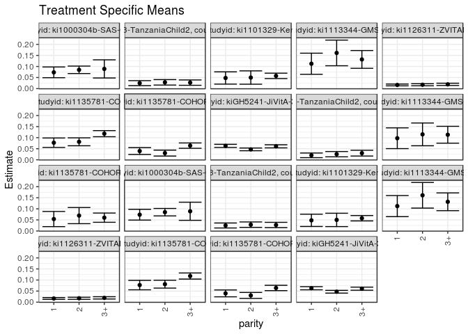

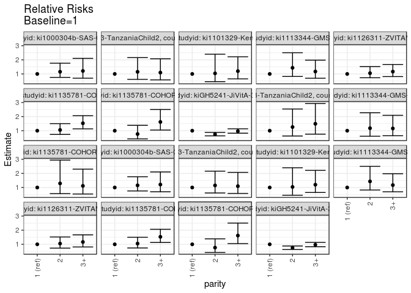

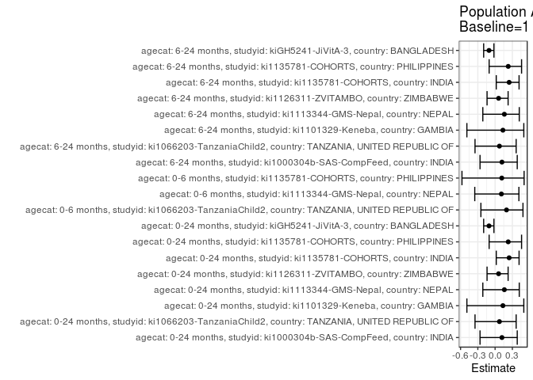

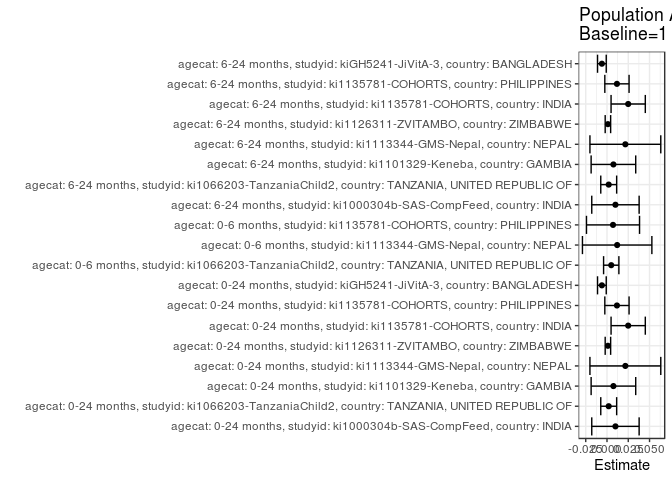

## Results Table

### Parameter: TSM

| agecat | studyid | country | intervention_level | baseline_level | estimate | ci_lower | ci_upper |
| --- | --- | --- | --- | --- | --- | --- | --- |
| 0-24 months | ki1000304b-SAS-CompFeed | INDIA | 1 | NA | 0.0735294 | 0.0491492 | 0.0979096 |
| 0-24 months | ki1000304b-SAS-CompFeed | INDIA | 2 | NA | 0.0849057 | 0.0680168 | 0.1017946 |
| 0-24 months | ki1000304b-SAS-CompFeed | INDIA | 3+ | NA | 0.0890625 | 0.0480466 | 0.1300784 |
| 0-24 months | ki1066203-TanzaniaChild2 | TANZANIA, UNITED REPUBLIC OF | 1 | NA | 0.0247253 | 0.0134424 | 0.0360081 |
| 0-24 months | ki1066203-TanzaniaChild2 | TANZANIA, UNITED REPUBLIC OF | 2 | NA | 0.0284495 | 0.0161569 | 0.0407421 |
| 0-24 months | ki1066203-TanzaniaChild2 | TANZANIA, UNITED REPUBLIC OF | 3+ | NA | 0.0271041 | 0.0150803 | 0.0391279 |
| 0-24 months | ki1101329-Keneba | GAMBIA | 1 | NA | 0.0480349 | 0.0203313 | 0.0757386 |
| 0-24 months | ki1101329-Keneba | GAMBIA | 2 | NA | 0.0500000 | 0.0197868 | 0.0802132 |
| 0-24 months | ki1101329-Keneba | GAMBIA | 3+ | NA | 0.0575843 | 0.0454815 | 0.0696870 |
| 0-24 months | ki1113344-GMS-Nepal | NEPAL | 1 | NA | 0.1124260 | 0.0647605 | 0.1600916 |
| 0-24 months | ki1113344-GMS-Nepal | NEPAL | 2 | NA | 0.1612903 | 0.1033399 | 0.2192407 |
| 0-24 months | ki1113344-GMS-Nepal | NEPAL | 3+ | NA | 0.1318681 | 0.0916989 | 0.1720374 |
| 0-24 months | ki1126311-ZVITAMBO | ZIMBABWE | 1 | NA | 0.0165615 | 0.0125057 | 0.0206173 |
| 0-24 months | ki1126311-ZVITAMBO | ZIMBABWE | 2 | NA | 0.0174419 | 0.0126966 | 0.0221871 |
| 0-24 months | ki1126311-ZVITAMBO | ZIMBABWE | 3+ | NA | 0.0192995 | 0.0142016 | 0.0243974 |
| 0-24 months | ki1135781-COHORTS | INDIA | 1 | NA | 0.0771812 | 0.0557523 | 0.0986101 |
| 0-24 months | ki1135781-COHORTS | INDIA | 2 | NA | 0.0812918 | 0.0634153 | 0.0991683 |
| 0-24 months | ki1135781-COHORTS | INDIA | 3+ | NA | 0.1180390 | 0.1042405 | 0.1318376 |
| 0-24 months | ki1135781-COHORTS | PHILIPPINES | 1 | NA | 0.0395387 | 0.0240333 | 0.0550441 |
| 0-24 months | ki1135781-COHORTS | PHILIPPINES | 2 | NA | 0.0303030 | 0.0168830 | 0.0437230 |
| 0-24 months | ki1135781-COHORTS | PHILIPPINES | 3+ | NA | 0.0640457 | 0.0519597 | 0.0761316 |
| 0-24 months | kiGH5241-JiVitA-3 | BANGLADESH | 1 | NA | 0.0628335 | 0.0557465 | 0.0699206 |
| 0-24 months | kiGH5241-JiVitA-3 | BANGLADESH | 2 | NA | 0.0470502 | 0.0408931 | 0.0532072 |
| 0-24 months | kiGH5241-JiVitA-3 | BANGLADESH | 3+ | NA | 0.0608390 | 0.0538487 | 0.0678293 |
| 0-6 months | ki1066203-TanzaniaChild2 | TANZANIA, UNITED REPUBLIC OF | 1 | NA | 0.0201439 | 0.0096963 | 0.0305915 |
| 0-6 months | ki1066203-TanzaniaChild2 | TANZANIA, UNITED REPUBLIC OF | 2 | NA | 0.0254111 | 0.0134832 | 0.0373390 |
| 0-6 months | ki1066203-TanzaniaChild2 | TANZANIA, UNITED REPUBLIC OF | 3+ | NA | 0.0300300 | 0.0170650 | 0.0429951 |
| 0-6 months | ki1113344-GMS-Nepal | NEPAL | 1 | NA | 0.0974026 | 0.0505317 | 0.1442735 |
| 0-6 months | ki1113344-GMS-Nepal | NEPAL | 2 | NA | 0.1148649 | 0.0634488 | 0.1662809 |
| 0-6 months | ki1113344-GMS-Nepal | NEPAL | 3+ | NA | 0.1132075 | 0.0750257 | 0.1513894 |
| 0-6 months | ki1135781-COHORTS | PHILIPPINES | 1 | NA | 0.0538922 | 0.0196251 | 0.0881594 |
| 0-6 months | ki1135781-COHORTS | PHILIPPINES | 2 | NA | 0.0695187 | 0.0330444 | 0.1059930 |
| 0-6 months | ki1135781-COHORTS | PHILIPPINES | 3+ | NA | 0.0601202 | 0.0392514 | 0.0809891 |
| 6-24 months | ki1000304b-SAS-CompFeed | INDIA | 1 | NA | 0.0735294 | 0.0491492 | 0.0979096 |
| 6-24 months | ki1000304b-SAS-CompFeed | INDIA | 2 | NA | 0.0849057 | 0.0680168 | 0.1017946 |
| 6-24 months | ki1000304b-SAS-CompFeed | INDIA | 3+ | NA | 0.0890625 | 0.0480466 | 0.1300784 |
| 6-24 months | ki1066203-TanzaniaChild2 | TANZANIA, UNITED REPUBLIC OF | 1 | NA | 0.0247253 | 0.0134424 | 0.0360081 |
| 6-24 months | ki1066203-TanzaniaChild2 | TANZANIA, UNITED REPUBLIC OF | 2 | NA | 0.0284495 | 0.0161569 | 0.0407421 |
| 6-24 months | ki1066203-TanzaniaChild2 | TANZANIA, UNITED REPUBLIC OF | 3+ | NA | 0.0271041 | 0.0150803 | 0.0391279 |
| 6-24 months | ki1101329-Keneba | GAMBIA | 1 | NA | 0.0480349 | 0.0203313 | 0.0757386 |
| 6-24 months | ki1101329-Keneba | GAMBIA | 2 | NA | 0.0500000 | 0.0197868 | 0.0802132 |
| 6-24 months | ki1101329-Keneba | GAMBIA | 3+ | NA | 0.0575843 | 0.0454815 | 0.0696870 |
| 6-24 months | ki1113344-GMS-Nepal | NEPAL | 1 | NA | 0.1124260 | 0.0647605 | 0.1600916 |
| 6-24 months | ki1113344-GMS-Nepal | NEPAL | 2 | NA | 0.1612903 | 0.1033399 | 0.2192407 |
| 6-24 months | ki1113344-GMS-Nepal | NEPAL | 3+ | NA | 0.1318681 | 0.0916989 | 0.1720374 |
| 6-24 months | ki1126311-ZVITAMBO | ZIMBABWE | 1 | NA | 0.0165615 | 0.0125057 | 0.0206173 |
| 6-24 months | ki1126311-ZVITAMBO | ZIMBABWE | 2 | NA | 0.0174419 | 0.0126966 | 0.0221871 |
| 6-24 months | ki1126311-ZVITAMBO | ZIMBABWE | 3+ | NA | 0.0192995 | 0.0142016 | 0.0243974 |
| 6-24 months | ki1135781-COHORTS | INDIA | 1 | NA | 0.0771812 | 0.0557523 | 0.0986101 |
| 6-24 months | ki1135781-COHORTS | INDIA | 2 | NA | 0.0812918 | 0.0634153 | 0.0991683 |
| 6-24 months | ki1135781-COHORTS | INDIA | 3+ | NA | 0.1180390 | 0.1042405 | 0.1318376 |
| 6-24 months | ki1135781-COHORTS | PHILIPPINES | 1 | NA | 0.0395387 | 0.0240333 | 0.0550441 |
| 6-24 months | ki1135781-COHORTS | PHILIPPINES | 2 | NA | 0.0303030 | 0.0168830 | 0.0437230 |
| 6-24 months | ki1135781-COHORTS | PHILIPPINES | 3+ | NA | 0.0640457 | 0.0519597 | 0.0761316 |
| 6-24 months | kiGH5241-JiVitA-3 | BANGLADESH | 1 | NA | 0.0628335 | 0.0557465 | 0.0699206 |
| 6-24 months | kiGH5241-JiVitA-3 | BANGLADESH | 2 | NA | 0.0470502 | 0.0408931 | 0.0532072 |
| 6-24 months | kiGH5241-JiVitA-3 | BANGLADESH | 3+ | NA | 0.0608390 | 0.0538487 | 0.0678293 |

### Parameter: E(Y)

| agecat | studyid | country | intervention_level | baseline_level | estimate | ci_lower | ci_upper |
| --- | --- | --- | --- | --- | --- | --- | --- |
| 0-24 months | ki1000304b-SAS-CompFeed | INDIA | NA | NA | 0.0834553 | 0.0601989 | 0.1067118 |
| 0-24 months | ki1066203-TanzaniaChild2 | TANZANIA, UNITED REPUBLIC OF | NA | NA | 0.0267355 | 0.0198866 | 0.0335843 |
| 0-24 months | ki1101329-Keneba | GAMBIA | NA | NA | 0.0555855 | 0.0451506 | 0.0660205 |
| 0-24 months | ki1113344-GMS-Nepal | NEPAL | NA | NA | 0.1340034 | 0.1066544 | 0.1613523 |
| 0-24 months | ki1126311-ZVITAMBO | ZIMBABWE | NA | NA | 0.0176359 | 0.0149926 | 0.0202793 |
| 0-24 months | ki1135781-COHORTS | INDIA | NA | NA | 0.1020862 | 0.0921879 | 0.1119845 |
| 0-24 months | ki1135781-COHORTS | PHILIPPINES | NA | NA | 0.0512273 | 0.0430760 | 0.0593786 |
| 0-24 months | kiGH5241-JiVitA-3 | BANGLADESH | NA | NA | 0.0568247 | 0.0527145 | 0.0609348 |
| 0-6 months | ki1066203-TanzaniaChild2 | TANZANIA, UNITED REPUBLIC OF | NA | NA | 0.0251232 | 0.0183136 | 0.0319327 |
| 0-6 months | ki1113344-GMS-Nepal | NEPAL | NA | NA | 0.1093474 | 0.0836377 | 0.1350572 |
| 0-6 months | ki1135781-COHORTS | PHILIPPINES | NA | NA | 0.0609613 | 0.0448957 | 0.0770269 |
| 6-24 months | ki1000304b-SAS-CompFeed | INDIA | NA | NA | 0.0834553 | 0.0601989 | 0.1067118 |
| 6-24 months | ki1066203-TanzaniaChild2 | TANZANIA, UNITED REPUBLIC OF | NA | NA | 0.0267355 | 0.0198866 | 0.0335843 |
| 6-24 months | ki1101329-Keneba | GAMBIA | NA | NA | 0.0555855 | 0.0451506 | 0.0660205 |
| 6-24 months | ki1113344-GMS-Nepal | NEPAL | NA | NA | 0.1340034 | 0.1066544 | 0.1613523 |
| 6-24 months | ki1126311-ZVITAMBO | ZIMBABWE | NA | NA | 0.0176359 | 0.0149926 | 0.0202793 |
| 6-24 months | ki1135781-COHORTS | INDIA | NA | NA | 0.1020862 | 0.0921879 | 0.1119845 |
| 6-24 months | ki1135781-COHORTS | PHILIPPINES | NA | NA | 0.0512273 | 0.0430760 | 0.0593786 |
| 6-24 months | kiGH5241-JiVitA-3 | BANGLADESH | NA | NA | 0.0568247 | 0.0527145 | 0.0609348 |

### Parameter: RR

| agecat | studyid | country | intervention_level | baseline_level | estimate | ci_lower | ci_upper |
| --- | --- | --- | --- | --- | --- | --- | --- |
| 0-24 months | ki1000304b-SAS-CompFeed | INDIA | 1 | 1 | 1.0000000 | 1.0000000 | 1.0000000 |
| 0-24 months | ki1000304b-SAS-CompFeed | INDIA | 2 | 1 | 1.1547170 | 0.7565289 | 1.7624855 |
| 0-24 months | ki1000304b-SAS-CompFeed | INDIA | 3+ | 1 | 1.2112500 | 0.6974280 | 2.1036243 |
| 0-24 months | ki1066203-TanzaniaChild2 | TANZANIA, UNITED REPUBLIC OF | 1 | 1 | 1.0000000 | 1.0000000 | 1.0000000 |
| 0-24 months | ki1066203-TanzaniaChild2 | TANZANIA, UNITED REPUBLIC OF | 2 | 1 | 1.1506243 | 0.6137724 | 2.1570475 |
| 0-24 months | ki1066203-TanzaniaChild2 | TANZANIA, UNITED REPUBLIC OF | 3+ | 1 | 1.0962118 | 0.5800975 | 2.0715142 |
| 0-24 months | ki1101329-Keneba | GAMBIA | 1 | 1 | 1.0000000 | 1.0000000 | 1.0000000 |
| 0-24 months | ki1101329-Keneba | GAMBIA | 2 | 1 | 1.0409091 | 0.4514782 | 2.3998758 |
| 0-24 months | ki1101329-Keneba | GAMBIA | 3+ | 1 | 1.1987998 | 0.6488715 | 2.2148005 |
| 0-24 months | ki1113344-GMS-Nepal | NEPAL | 1 | 1 | 1.0000000 | 1.0000000 | 1.0000000 |
| 0-24 months | ki1113344-GMS-Nepal | NEPAL | 2 | 1 | 1.4346350 | 0.8229774 | 2.5008919 |
| 0-24 months | ki1113344-GMS-Nepal | NEPAL | 3+ | 1 | 1.1729323 | 0.6958991 | 1.9769679 |
| 0-24 months | ki1126311-ZVITAMBO | ZIMBABWE | 1 | 1 | 1.0000000 | 1.0000000 | 1.0000000 |
| 0-24 months | ki1126311-ZVITAMBO | ZIMBABWE | 2 | 1 | 1.0531561 | 0.7303341 | 1.5186719 |
| 0-24 months | ki1126311-ZVITAMBO | ZIMBABWE | 3+ | 1 | 1.1653222 | 0.8128546 | 1.6706257 |
| 0-24 months | ki1135781-COHORTS | INDIA | 1 | 1 | 1.0000000 | 1.0000000 | 1.0000000 |
| 0-24 months | ki1135781-COHORTS | INDIA | 2 | 1 | 1.0532584 | 0.7391217 | 1.5009075 |
| 0-24 months | ki1135781-COHORTS | INDIA | 3+ | 1 | 1.5293752 | 1.1315744 | 2.0670215 |
| 0-24 months | ki1135781-COHORTS | PHILIPPINES | 1 | 1 | 1.0000000 | 1.0000000 | 1.0000000 |
| 0-24 months | ki1135781-COHORTS | PHILIPPINES | 2 | 1 | 0.7664141 | 0.4241932 | 1.3847242 |
| 0-24 months | ki1135781-COHORTS | PHILIPPINES | 3+ | 1 | 1.6198214 | 1.0482449 | 2.5030614 |
| 0-24 months | kiGH5241-JiVitA-3 | BANGLADESH | 1 | 1 | 1.0000000 | 1.0000000 | 1.0000000 |
| 0-24 months | kiGH5241-JiVitA-3 | BANGLADESH | 2 | 1 | 0.7488068 | 0.6365146 | 0.8809091 |
| 0-24 months | kiGH5241-JiVitA-3 | BANGLADESH | 3+ | 1 | 0.9682570 | 0.8255424 | 1.1356431 |
| 0-6 months | ki1066203-TanzaniaChild2 | TANZANIA, UNITED REPUBLIC OF | 1 | 1 | 1.0000000 | 1.0000000 | 1.0000000 |
| 0-6 months | ki1066203-TanzaniaChild2 | TANZANIA, UNITED REPUBLIC OF | 2 | 1 | 1.2614777 | 0.6267314 | 2.5390878 |
| 0-6 months | ki1066203-TanzaniaChild2 | TANZANIA, UNITED REPUBLIC OF | 3+ | 1 | 1.4907765 | 0.7591695 | 2.9274287 |
| 0-6 months | ki1113344-GMS-Nepal | NEPAL | 1 | 1 | 1.0000000 | 1.0000000 | 1.0000000 |
| 0-6 months | ki1113344-GMS-Nepal | NEPAL | 2 | 1 | 1.1792792 | 0.6112141 | 2.2753067 |
| 0-6 months | ki1113344-GMS-Nepal | NEPAL | 3+ | 1 | 1.1622641 | 0.6458006 | 2.0917571 |
| 0-6 months | ki1135781-COHORTS | PHILIPPINES | 1 | 1 | 1.0000000 | 1.0000000 | 1.0000000 |
| 0-6 months | ki1135781-COHORTS | PHILIPPINES | 2 | 1 | 1.2899584 | 0.5656642 | 2.9416615 |
| 0-6 months | ki1135781-COHORTS | PHILIPPINES | 3+ | 1 | 1.1155645 | 0.5406060 | 2.3020166 |
| 6-24 months | ki1000304b-SAS-CompFeed | INDIA | 1 | 1 | 1.0000000 | 1.0000000 | 1.0000000 |
| 6-24 months | ki1000304b-SAS-CompFeed | INDIA | 2 | 1 | 1.1547170 | 0.7565289 | 1.7624855 |
| 6-24 months | ki1000304b-SAS-CompFeed | INDIA | 3+ | 1 | 1.2112500 | 0.6974280 | 2.1036243 |
| 6-24 months | ki1066203-TanzaniaChild2 | TANZANIA, UNITED REPUBLIC OF | 1 | 1 | 1.0000000 | 1.0000000 | 1.0000000 |
| 6-24 months | ki1066203-TanzaniaChild2 | TANZANIA, UNITED REPUBLIC OF | 2 | 1 | 1.1506243 | 0.6137724 | 2.1570475 |
| 6-24 months | ki1066203-TanzaniaChild2 | TANZANIA, UNITED REPUBLIC OF | 3+ | 1 | 1.0962118 | 0.5800975 | 2.0715142 |
| 6-24 months | ki1101329-Keneba | GAMBIA | 1 | 1 | 1.0000000 | 1.0000000 | 1.0000000 |
| 6-24 months | ki1101329-Keneba | GAMBIA | 2 | 1 | 1.0409091 | 0.4514782 | 2.3998758 |
| 6-24 months | ki1101329-Keneba | GAMBIA | 3+ | 1 | 1.1987998 | 0.6488715 | 2.2148005 |
| 6-24 months | ki1113344-GMS-Nepal | NEPAL | 1 | 1 | 1.0000000 | 1.0000000 | 1.0000000 |
| 6-24 months | ki1113344-GMS-Nepal | NEPAL | 2 | 1 | 1.4346350 | 0.8229774 | 2.5008919 |
| 6-24 months | ki1113344-GMS-Nepal | NEPAL | 3+ | 1 | 1.1729323 | 0.6958991 | 1.9769679 |
| 6-24 months | ki1126311-ZVITAMBO | ZIMBABWE | 1 | 1 | 1.0000000 | 1.0000000 | 1.0000000 |
| 6-24 months | ki1126311-ZVITAMBO | ZIMBABWE | 2 | 1 | 1.0531561 | 0.7303341 | 1.5186719 |
| 6-24 months | ki1126311-ZVITAMBO | ZIMBABWE | 3+ | 1 | 1.1653222 | 0.8128546 | 1.6706257 |
| 6-24 months | ki1135781-COHORTS | INDIA | 1 | 1 | 1.0000000 | 1.0000000 | 1.0000000 |
| 6-24 months | ki1135781-COHORTS | INDIA | 2 | 1 | 1.0532584 | 0.7391217 | 1.5009075 |
| 6-24 months | ki1135781-COHORTS | INDIA | 3+ | 1 | 1.5293752 | 1.1315744 | 2.0670215 |
| 6-24 months | ki1135781-COHORTS | PHILIPPINES | 1 | 1 | 1.0000000 | 1.0000000 | 1.0000000 |
| 6-24 months | ki1135781-COHORTS | PHILIPPINES | 2 | 1 | 0.7664141 | 0.4241932 | 1.3847242 |
| 6-24 months | ki1135781-COHORTS | PHILIPPINES | 3+ | 1 | 1.6198214 | 1.0482449 | 2.5030614 |
| 6-24 months | kiGH5241-JiVitA-3 | BANGLADESH | 1 | 1 | 1.0000000 | 1.0000000 | 1.0000000 |
| 6-24 months | kiGH5241-JiVitA-3 | BANGLADESH | 2 | 1 | 0.7488068 | 0.6365146 | 0.8809091 |
| 6-24 months | kiGH5241-JiVitA-3 | BANGLADESH | 3+ | 1 | 0.9682570 | 0.8255424 | 1.1356431 |

### Parameter: PAR

| agecat | studyid | country | intervention_level | baseline_level | estimate | ci_lower | ci_upper |
| --- | --- | --- | --- | --- | --- | --- | --- |
| 0-24 months | ki1000304b-SAS-CompFeed | INDIA | 1 | NA | 0.0099259 | -0.0179202 | 0.0377721 |
| 0-24 months | ki1066203-TanzaniaChild2 | TANZANIA, UNITED REPUBLIC OF | 1 | NA | 0.0020102 | -0.0073317 | 0.0113521 |
| 0-24 months | ki1101329-Keneba | GAMBIA | 1 | NA | 0.0075506 | -0.0186540 | 0.0337552 |
| 0-24 months | ki1113344-GMS-Nepal | NEPAL | 1 | NA | 0.0215773 | -0.0200597 | 0.0632143 |
| 0-24 months | ki1126311-ZVITAMBO | ZIMBABWE | 1 | NA | 0.0010744 | -0.0021348 | 0.0042837 |
| 0-24 months | ki1135781-COHORTS | INDIA | 1 | NA | 0.0249050 | 0.0047825 | 0.0450276 |
| 0-24 months | ki1135781-COHORTS | PHILIPPINES | 1 | NA | 0.0116886 | -0.0025603 | 0.0259375 |
| 0-24 months | kiGH5241-JiVitA-3 | BANGLADESH | 1 | NA | -0.0060089 | -0.0111231 | -0.0008946 |
| 0-6 months | ki1066203-TanzaniaChild2 | TANZANIA, UNITED REPUBLIC OF | 1 | NA | 0.0049793 | -0.0040086 | 0.0139672 |
| 0-6 months | ki1113344-GMS-Nepal | NEPAL | 1 | NA | 0.0119448 | -0.0288535 | 0.0527432 |
| 0-6 months | ki1135781-COHORTS | PHILIPPINES | 1 | NA | 0.0070691 | -0.0241168 | 0.0382550 |
| 6-24 months | ki1000304b-SAS-CompFeed | INDIA | 1 | NA | 0.0099259 | -0.0179202 | 0.0377721 |
| 6-24 months | ki1066203-TanzaniaChild2 | TANZANIA, UNITED REPUBLIC OF | 1 | NA | 0.0020102 | -0.0073317 | 0.0113521 |
| 6-24 months | ki1101329-Keneba | GAMBIA | 1 | NA | 0.0075506 | -0.0186540 | 0.0337552 |
| 6-24 months | ki1113344-GMS-Nepal | NEPAL | 1 | NA | 0.0215773 | -0.0200597 | 0.0632143 |
| 6-24 months | ki1126311-ZVITAMBO | ZIMBABWE | 1 | NA | 0.0010744 | -0.0021348 | 0.0042837 |
| 6-24 months | ki1135781-COHORTS | INDIA | 1 | NA | 0.0249050 | 0.0047825 | 0.0450276 |
| 6-24 months | ki1135781-COHORTS | PHILIPPINES | 1 | NA | 0.0116886 | -0.0025603 | 0.0259375 |
| 6-24 months | kiGH5241-JiVitA-3 | BANGLADESH | 1 | NA | -0.0060089 | -0.0111231 | -0.0008946 |

### Parameter: PAF

| agecat | studyid | country | intervention_level | baseline_level | estimate | ci_lower | ci_upper |
| --- | --- | --- | --- | --- | --- | --- | --- |
| 0-24 months | ki1000304b-SAS-CompFeed | INDIA | 1 | NA | 0.1189370 | -0.2617197 | 0.3847509 |
| 0-24 months | ki1066203-TanzaniaChild2 | TANZANIA, UNITED REPUBLIC OF | 1 | NA | 0.0751880 | -0.3486669 | 0.3658350 |
| 0-24 months | ki1101329-Keneba | GAMBIA | 1 | NA | 0.1358375 | -0.4900656 | 0.4988296 |
| 0-24 months | ki1113344-GMS-Nepal | NEPAL | 1 | NA | 0.1610207 | -0.2131793 | 0.4198003 |
| 0-24 months | ki1126311-ZVITAMBO | ZIMBABWE | 1 | NA | 0.0609227 | -0.1396065 | 0.2261661 |
| 0-24 months | ki1135781-COHORTS | INDIA | 1 | NA | 0.2439606 | 0.0202944 | 0.4165640 |
| 0-24 months | ki1135781-COHORTS | PHILIPPINES | 1 | NA | 0.2281713 | -0.1035805 | 0.4601939 |
| 0-24 months | kiGH5241-JiVitA-3 | BANGLADESH | 1 | NA | -0.1057442 | -0.1984395 | -0.0202186 |
| 0-6 months | ki1066203-TanzaniaChild2 | TANZANIA, UNITED REPUBLIC OF | 1 | NA | 0.1981944 | -0.2466347 | 0.4842978 |
| 0-6 months | ki1113344-GMS-Nepal | NEPAL | 1 | NA | 0.1092375 | -0.3531155 | 0.4136067 |
| 0-6 months | ki1135781-COHORTS | PHILIPPINES | 1 | NA | 0.1159604 | -0.5753898 | 0.5039158 |
| 6-24 months | ki1000304b-SAS-CompFeed | INDIA | 1 | NA | 0.1189370 | -0.2617197 | 0.3847509 |
| 6-24 months | ki1066203-TanzaniaChild2 | TANZANIA, UNITED REPUBLIC OF | 1 | NA | 0.0751880 | -0.3486669 | 0.3658350 |
| 6-24 months | ki1101329-Keneba | GAMBIA | 1 | NA | 0.1358375 | -0.4900656 | 0.4988296 |
| 6-24 months | ki1113344-GMS-Nepal | NEPAL | 1 | NA | 0.1610207 | -0.2131793 | 0.4198003 |
| 6-24 months | ki1126311-ZVITAMBO | ZIMBABWE | 1 | NA | 0.0609227 | -0.1396065 | 0.2261661 |
| 6-24 months | ki1135781-COHORTS | INDIA | 1 | NA | 0.2439606 | 0.0202944 | 0.4165640 |
| 6-24 months | ki1135781-COHORTS | PHILIPPINES | 1 | NA | 0.2281713 | -0.1035805 | 0.4601939 |
| 6-24 months | kiGH5241-JiVitA-3 | BANGLADESH | 1 | NA | -0.1057442 | -0.1984395 | -0.0202186 |